```python
import pylab as pl
from  numpy.random import normal
import numpy as np
import healpy as hp
from scipy  import  signal, special , stats
from scipy.signal import periodogram

from pylab import cm
cmap = cm.get_cmap('RdYlBu')
cmap.set_under('w')
import scipy.stats as spt
from scipy import interpolate

folder = '/Users/peppe/work/satellite_sims/'
def bin_gains(tau, fs,obs,  g) :
    sizech = pl.int_( tau *fs)  ; nch =pl.int_(  obs *fs*3600  /sizech)
    gb = pl.zeros(nch)
    for i in range (nch):
        gb[i] =g[slice(i*sizech, (i+1)*sizech)] .mean()
    return gb
fs=20
#from ipywidgets import interact, interactive, fixed, interact_manual
```

```python
from IPython.display import HTML

HTML('''<script>
code_show=true;
function code_toggle() {
 if (code_show){
 $('div.input').hide();
 } else {
 $('div.input').show();
 }
 code_show = !code_show
}
$( document ).ready(code_toggle);
</script>
<form action="javascript:code_toggle()"><input type="submit" value="Click here to toggle on/off the raw code."></form>''')
```

# 1. Summary

10/20/2019

*In this posting I show that we are able to track $\sim10$ percent gain fluctuations on the time scale of up to 1 minute by regressing the time samples (including noise and sky signal) with CMB Temperature template map.* Moreover, smaller gain fluctuations (order of few per cents) are harder to track because noise affects the estimates, in this case a longer time scale for the gain estimation might be helpful. With respect to previous postings, the high pass filter adopted in this analysis is a *Legendre* polynomial filtering. To get rid of the higher order leakage coming from Monopole and Dipole due to gain drift we have to filter up to the 4th order. We apply this filtering on a chuncks of TODs related to the time scale $\tau$ we wanna perform the gain regression.

### Simulation setups

#### Gain drift sim

Simulate per detector a time stream signal $g(t)$ fluctuating around 1 with a low frequency component with a 1/f dependence $fknee = 150 $ mHz .

Multiply $g$ by the detector TOD.

#### Gain estimation

The procedure to mitigate gain mismatches is performed on each chunck (related to $\tau$) of time samples $d_{t , t+\tau}$ of a given detector:

1. Apply filter to $d_{t , t+\tau} $
2. Regress $d_{t , t+\tau} $ against signal-only template $T$ and estimate the regression slope $\hat{g}$ as $$ \hat{g} = \frac { T^{t} d } { T^{t} T } $$
3. Mitigate the leakage, dividing $d_{t , t+\tau} $ by $\hat{g}$

## Tracking Gain Drifts

In the plots below, we show in solid blue the Gain drift we have injected to the data as a function of time and we compare them with our gain estimates at a given $\tau$.

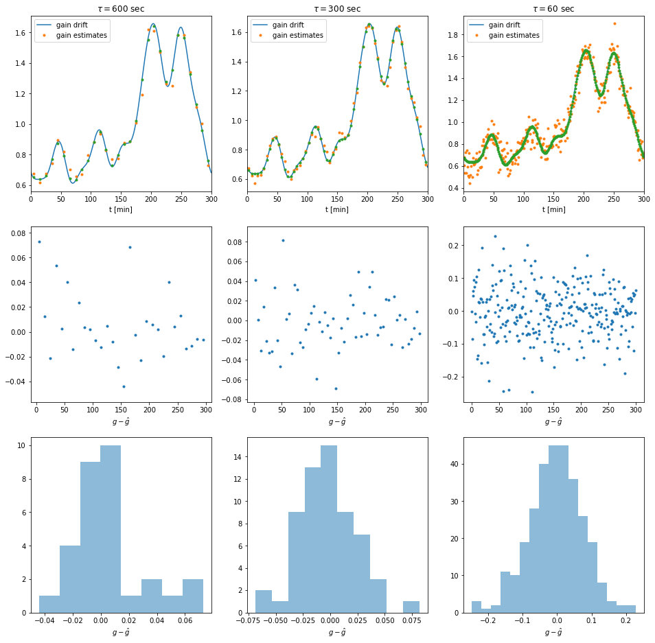

```python
pl.figure(figsize=(16,16))
obs=5.
folder = '/Users/peppe/work/satellite_sims/'

pl.subplot(331)
tau10 =600
pl.title(r'$\tau= {} $ sec'.format(tau10))

fs=20
g=pl.load(folder+ 'gain_drift.npy')
N = len(g[0] )

gb = [ bin_gains(tau10,fs, obs,g[0,:]) , bin_gains(tau10,fs, obs,g[ 1,:] ) ]

ge  = pl.load(folder+'gains_coeff_'+str(tau10)+'.npy')
t=  pl.arange(N)/60. /fs
obs =5.
pl.plot(t,1+ g[1 ], label='gain drift')
#print(ge[1,0,:]/60/ fs)
pl.plot(ge[1,0,:]/ 60/fs
        , ge[1,1,:], '.', label = 'gain estimates')
pl.plot(ge[1,0,:]/ 60/fs
        , gb[1] +1, '.' )
pl.xlabel('t [min]')
pl.legend()

pl.xlim((0,300 ))
pl.subplot(337)

_ = pl.hist((1+ gb[0]) -ge[0,1,: ],bins='auto', alpha=.5 )

_=pl.xlabel(r'$g - \hat{g} $')

pl.subplot(334)
#r=spt.linregress((1+ gb[0]), ge[0,1,: ])[2]
pl.scatter(ge[1,0,:]/ 60/fs , (1+ gb[0]) -ge[0,1,: ], marker='.' )
_=pl.xlabel(r'$g - \hat{g} $')

pl.subplot(332)

tau10 =300
pl.title(r'$\tau= {} $ sec'.format(tau10))

fs=20
g=pl.load(folder+ 'gain_drift.npy')
N = len(g[0] )

gb = [ bin_gains(tau10,fs, obs,g[0,:]) , bin_gains(tau10,fs, obs,g[ 1,:] ) ]

ge  = pl.load(folder+'gains_coeff_'+str(tau10)+'.npy')
t=  pl.arange(N)/60. /fs
obs =5.
pl.plot(t,1+ g[1 ], label='gain drift')
#print(ge[1,0,:]/60/ fs)
pl.plot(ge[1,0,:]/ 60/fs
        , ge[1,1,:], '.', label = 'gain estimates')
pl.plot(ge[1,0,:]/ 60/fs
        , gb[1]+1 , '.' )
pl.xlabel('t [min]')
pl.legend()
pl.xlim((0,300 ))
pl.subplot(335)
#r=spt.linregress((1+ gb[0]), ge[0,1,: ])[2]
pl.scatter(ge[1,0,:]/ 60/fs , (1+ gb[0]) -ge[0,1,: ], marker='.' )
_=pl.xlabel(r'$g - \hat{g} $')

pl.subplot(338)

_ = pl.hist((1+ gb[0]) -ge[0,1,: ],bins='auto', alpha=.5 )
_=pl.xlabel(r'$g - \hat{g} $')

pl.subplot(333)
tau10 =60
pl.title(r'$\tau= {} $ sec'.format(tau10))

fs=20
g=pl.load(folder+ 'gain_drift.npy')
N = len(g[0] )

gb = [ bin_gains(tau10,fs, obs,g[0,:]) , bin_gains(tau10,fs, obs,g[ 1,:] ) ]

ge  = pl.load(folder+'gains_coeff_'+str(tau10)+'.npy')
t=  pl.arange(N)/60. /fs
obs =5.
pl.plot(t,1+ g[1 ], label='gain drift')
#print(ge[1,0,:]/60/ fs)
pl.plot(ge[1,0,:]/ 60/fs
        , ge[1,1,:], '.', label = 'gain estimates')
pl.plot(ge[1,0,:]/ 60/fs
        , gb[1]+1 , '.' )
pl.xlabel('t [min]')
pl.legend()
pl.xlim((0,300 ))
pl.subplot(336)
#r=spt.linregress((1+ gb[0]), ge[0,1,: ])[2]
pl.scatter(ge[1,0,:]/ 60/fs , (1+ gb[0]) -ge[0,1,: ], marker='.' )
_=pl.xlabel(r'$g - \hat{g} $')




pl.subplot(339)
_ = pl.hist((1+ gb[0]) -ge[0,1,: ],bins='auto', alpha=.5 )
_=pl.xlabel(r'$g - \hat{g} $')
```

Notice that the smaller $ \tau$ the larger is the amplitude of the outliers. This is expected and it is due to signal -to-noise ratio, which decreases as large frequencies are filtered out from the samples.

## Effects of gain drifts to the TODs

In the plot below, we show the TODs for the pair diff and pair sums of the intrinsic astrophysical signal and we compare it with the TODs including the gain systematics.

### Pair Sum

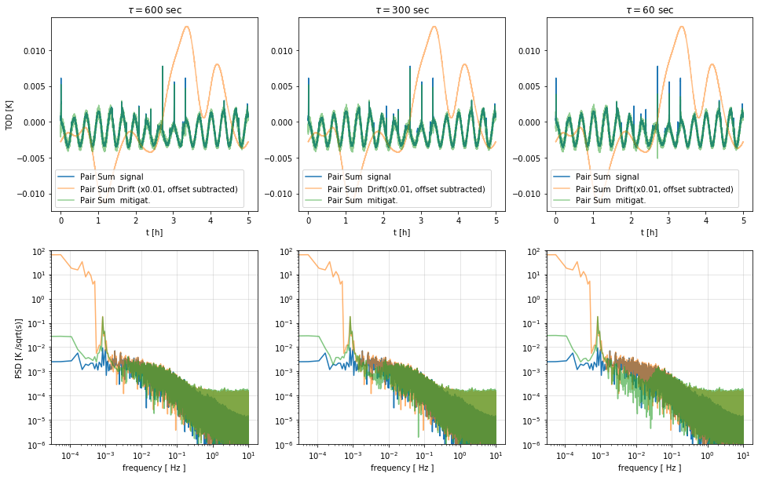

```python
def showperpair(Pair):
    folder = '/Users/peppe/work/satellite_sims/'

    fs = 20
    tau10=600
    sig  =pl.load(folder+'signaltod.npy')
    dipole = pl.load(folder+'dipole.npy')
    filt = pl.load(folder+'filttod.npy')
    dri  =pl.load(folder+'drifttod.npy')
    mit   = pl.load(folder+'mittod_'+str(tau10)+'.npy')
    sums =.5* ( sig[0,:]   +sig[1,: ] )
    difs =.5* ( sig[0,:] - sig[1,: ])

    sumd =.5* ( dri[0,:] +dri[1,: ])
    difd =.5* ( dri[0,:] - dri[1,: ])
    summ =.5* ( mit [0,:] +mit [1,: ])
    difm =.5* ( mit [0,:]  - mit [1,: ])
    sumf =.5* (filt[0,:] +filt[1,: ])
    diff =.5* ( filt[0,:] - filt[1,: ])



    fs=20


    dicx = {  0:'sum',  1:'diff'   }
    t=  pl.arange(len(difm))/3600. /fs
    pl.figure(figsize=(16,10) )
    pl.subplot(231)
    pl.title(r'$\tau= {} $ sec'.format(tau10))

    pl.ylabel('TOD [K]')
    if Pair :
        # pair  diff
        f,pdc  = periodogram(  (  difm),  fs=fs, scaling='density')
        f,pds  = periodogram(  (  difs),  fs=fs, scaling='density')
        f,pd  = periodogram(  (  difd),  fs=fs, scaling='density')
        #f,pdf  = periodogram(  (  diff),  fs=fs, scaling='density')

        pl.plot(t, (  difs)  , label='Pair Diff signal' );
        pl.plot(t, (  difd -difd.mean() )/100 ,alpha=.5, label='Pair dif drift (x0.01, offset subtracted) ' )
        pl.plot(t,  ( difm),alpha=.5, label='Pair dif  mitigat. ')
    else:
        f,pds= periodogram( sums ,fs=fs, scaling='density')
        f,pd= periodogram(  (  sumd)
                  ,fs=fs, scaling='density')
        #f,pdf= periodogram(  (  sumf)
        #          ,fs=fs, scaling='density')
        f,pdc  = periodogram(  (  summ),  fs=fs, scaling='density')

        pl.plot(t,  (  sums) +dipole , label='Pair Sum  signal'  );
        pl.plot(t, (  sumd  - sumd.mean())/100   ,alpha=.5 , label='Pair Sum Drift (x0.01, offset subtracted) '  );

        pl.plot(t,  (  summ),alpha=.5 , label='Pair Sum  mitigat.');

    pl.legend()
    pl.xlabel('t [h]')
    pl.subplot(234)
    pl.ylim((1e-6,1e2))
    pl.ylabel('PSD [K /sqrt(s)]')
    pl.xlabel('frequency [ Hz ]')

    pl.loglog(f , pl.sqrt(pds) , label='Pair Sum Signal-only ')
    pl.loglog(f , pl.sqrt(pd),   alpha=.6 , label='Pair Sum   w/ Drift')
    #pl.loglog(f , pl.sqrt(pdf),   alpha=.6 , label='Pair Sum Signal w/ Drift HPF ')

    pl.loglog(f , pl.sqrt(pdc) ,  alpha=.6 , label='Pair Sum Signal w/ Mitigatiton')
    pl.grid(True, alpha=.4 )

    pl.subplot(232)
    tau10=300
    pl.title(r'$\tau= {} $ sec'.format(tau10))

    mit   = pl.load(folder+'mittod_'+str(tau10)+'.npy')
    summ =.5* ( mit [0,:] +mit [1,: ])
    difm =.5* ( mit [0,:]  - mit [1,: ])
    if Pair :
        # pair  diff
        f,pdc  = periodogram(  (  difm),  fs=fs, scaling='density')
        pl.plot(t, (  difs)  , label='Pair Diff signal' );
        pl.plot(t,  (  difd -difd.mean() )/100,alpha=.5, label='Pair dif drift(x0.01, offset subtracted)' )
        pl.plot(t,  ( difm),alpha=.5, label='Pair dif  mitigat. ')
    else:


        f,pdc  = periodogram(  (  summ),  fs=fs, scaling='density')

        pl.plot(t,  (  sums) +dipole , label='Pair Sum  signal'  );
        pl.plot(t, (  sumd  - sumd.mean())/100,alpha=.5 , label='Pair Sum  Drift(x0.01, offset subtracted) '  );

        pl.plot(t,  (  summ),alpha=.5 , label='Pair Sum  mitigat.');

    pl.legend()
    pl.xlabel('t [h]')
    pl.subplot(235)
    pl.ylim((1e-6,1e2))
    pl.xlabel('frequency [ Hz ]')

    pl.loglog(f , pl.sqrt(pds)   , label='Pair Sum Signal-only ')
    pl.loglog(f , pl.sqrt(pd),   alpha=.6 , label='Pair Sum Signal w/ Drift ')
    #pl.loglog(f , pl.sqrt(pdf),   alpha=.6 , label='Pair Sum Signal w/ Drift HPF ')
    pl.loglog(f , pl.sqrt(pdc) ,  alpha=.6, label='Pair Sum Signal w/ Mitigatiton')

    pl.grid(True, alpha=.4 )

    pl.subplot(233)
    tau10=60
    pl.title(r'$\tau= {} $ sec'.format(tau10))

    mit   = pl.load(folder+'mittod_'+str(tau10)+'.npy')
    summ =.5* ( mit [0,:] +mit [1,: ])
    difm =.5* ( mit [0,:]  - mit [1,: ])
    if Pair :
        # pair  diff
        f,pdc  = periodogram(  (  difm),  fs=fs, scaling='density')


        pl.plot(t, (  difs)  , label='Pair Diff signal' );
        pl.plot(t, ((  difd -difd.mean() )/100),alpha=.5, label='Pair dif drift(x0.01, offset subtracted) ' )
        pl.plot(t,  ( difm),alpha=.5, label='Pair dif  mitigat. ')
    else:

        f,pdc  = periodogram(  (  summ),  fs=fs, scaling='density')

        pl.plot(t,  (  sums) +dipole  , label='Pair Sum  signal'  );
        pl.plot(t, (  sumd  - sumd.mean())/100,alpha=.5 , label='Pair Sum  Drift(x0.01, offset subtracted) '  );

        pl.plot(t,  (  summ),alpha=.5 , label='Pair Sum  mitigat.');

    pl.legend()
    pl.xlabel('t [h]')
    pl.subplot(236)
    pl.ylim((1e-6,1e2))
    pl.xlabel('frequency [ Hz ]')

    pl.loglog(f , pl.sqrt(pds) , label='Pair Sum Signal-only ')
    pl.loglog(f , pl.sqrt(pd),   alpha=.6 , label='Pair Sum Signal w/ Drift ')

    #pl.loglog(f , pl.sqrt(pdf),   alpha=.6 , label='Pair Sum Signal w/ Drift HPF ')
    pl.loglog(f , pl.sqrt(pdc) ,  alpha=.6 , label='Pair Sum Signal w/ Mitigatiton')
    pl.grid(True, alpha=.4 )


showperpair(0)
```

**Fig2** (top) Pair sum TOD from 5 hours of LB sims. (solid blue) signal-only TOD without noise and gain drift, (solid orange) TOD encoding signal noise and gain drift, (for graphical purposes we remove the offset and scale it by 1%), (solid green) TOD with the mitigation has been applied every 10,5, and 1 minutes respectively going from left to right. (bottom) PSD of TODs shown in the top panels, we kept the same color scheme.

The peak at around 1 mHz is an effect of dipole modulation due to the spin period, (e.g. see solid blue and green TODs in the top panel). *Notice that we observe in the post-mitigation PSD (green ) a reduction of power below $1 $ mHZ, implying that the drift has been mitigated. Moreover, one may notice the troughs in the PSD at frequencies exactly around $\tau^{-1}$. This is the expected effect due to the filtering time scale adopted to perform the gain estimates.* At larger frequencies, the signal follows the input ones, noise starts to kick in at $>100 $ mHz.

### Pair Diff

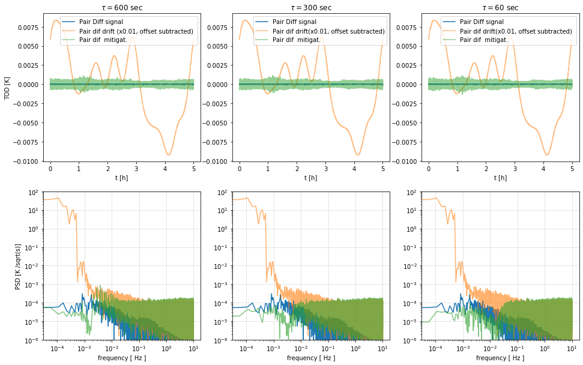

```python
showperpair(1)
```

**Fig3** (top) Pair diff TOD from 5 hours of LB sims. (solid blue) signal-only TOD without noise and gain drift, (solid orange) TOD encoding signal noise and gain drift, (for graphical purposes we remove the offset and scale it by 1%), (solid green) TOD with the mitigation has been applied every 10,5, and 1 minutes respectively going from left to right. (bottom) PSD of TODs shown in the top panels, we kept the same color scheme.

Also in this case we notice a decrease due to filtering at frequencies below $ \tau^{-1}$. At larger frequencies, the signal is essentially dominated by noise, **but we can clearly notice a reduction of the 1/f due to gain drift when we compare the pair diff with gain drifts (solid orange) and the one with drifts mitigated (solid green).**

We claim that this reduction of power is an effect of the gain mitigation we 've applied and not just a high pass filtering effect. In the plot below, we compare the PSD of pair diff filtered TOD with gain drifts and the one of pair diff filtered TOD w/ mitigated gain drifts.

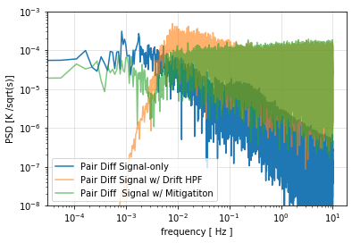

```python
 def showfilt(Pair):
    folder = '/Users/peppe/work/satellite_sims/'

    fs = 20
    tau10=300
    filt = pl.load(folder+'filttod.npy')
    mit   = pl.load(folder+'mittod_'+str(tau10)+'.npy')
    sig  =pl.load(folder+'signaltod.npy')

    summ =.5* ( mit [0,:] +mit [1,: ])
    difm =.5* ( mit [0,:]  - mit [1,: ])
    sumf =.5* (filt[0,:] +filt[1,: ])
    diff =.5* ( filt[0,:] - filt[1,: ])
    sums =.5* ( sig[0,:]   +sig[1,: ] )
    difs =.5* ( sig[0,:] - sig[1,: ])
    fs=20
    dicx = {  0:'sum',  1:'diff'   }
    t=  pl.arange(len(difm))/3600. /fs
    #pl.figure(figsize=(16,10) )
    if Pair :
        # pair  diff
        f,pdc  = periodogram(  (  difm),  fs=fs, scaling='density')
        f,pdf  = periodogram(  (  diff),  fs=fs, scaling='density')
        f,pds  = periodogram(  (  difs),  fs=fs, scaling='density')

    else:
        f,pdf= periodogram(  (  sumf)
                  ,fs=fs, scaling='density')
        f,pdc  = periodogram(  (  summ),  fs=fs, scaling='density')

    pl.subplot(111)
    pl.ylim((1e-8,1e-3))
    pl.ylabel('PSD [K /sqrt(s)]')
    pl.xlabel('frequency [ Hz ]')

    pl.loglog(f , pl.sqrt(pds) , label='Pair Diff Signal-only ')
    pl.loglog(f , pl.sqrt(pdf),   alpha=.6 , label='Pair Diff Signal w/ Drift HPF ')
    pl.loglog(f , pl.sqrt(pdc) ,  alpha=.6 , label='Pair Diff  Signal w/ Mitigatiton')
    pl.grid(True, alpha=.4 )
    pl.legend()
showfilt(1)
```

**Fig4** (solid blue) PSD of pair diff signal only, (solid orange) PSD of pair diff with gain drifts and with high-pass filtering (freq. cutoff 3 mHz), (solid green) PSD of pair diff with mitigated gain drifts. As expected the high-pass filtered TOD with drifts has a fknee at around 150 mHz, (which is the chosen fknee for our sims), whereas the mitigated TOD shows a flatter PSD.

## Future Outlooks

- The whole pipeline has been thoroughly tested and debugged and shows promising results when gain mitigation is performed every 5 minutes using CMB T as a regression template.
- The signal is fully recovered at frequencies above the chosen mitigation time scale, i.e. $\ell \gtrsim 30$.
- Next: perform 1 yr LB simulation and check the effects onto maps and power spectra.